# Cypher and SQL and Js

Farnoosh Koleini

2023-03-18

**1. Relational database schema design (10 pts)**

# creating a table for accidents

CREATE TABLE IF NOT EXISTS public.accidents ( “Accident_Index” character varying(255) COLLATE pg_catalog.”default”, “Accident_Severity” character varying(255) COLLATE pg_catalog.”default” )

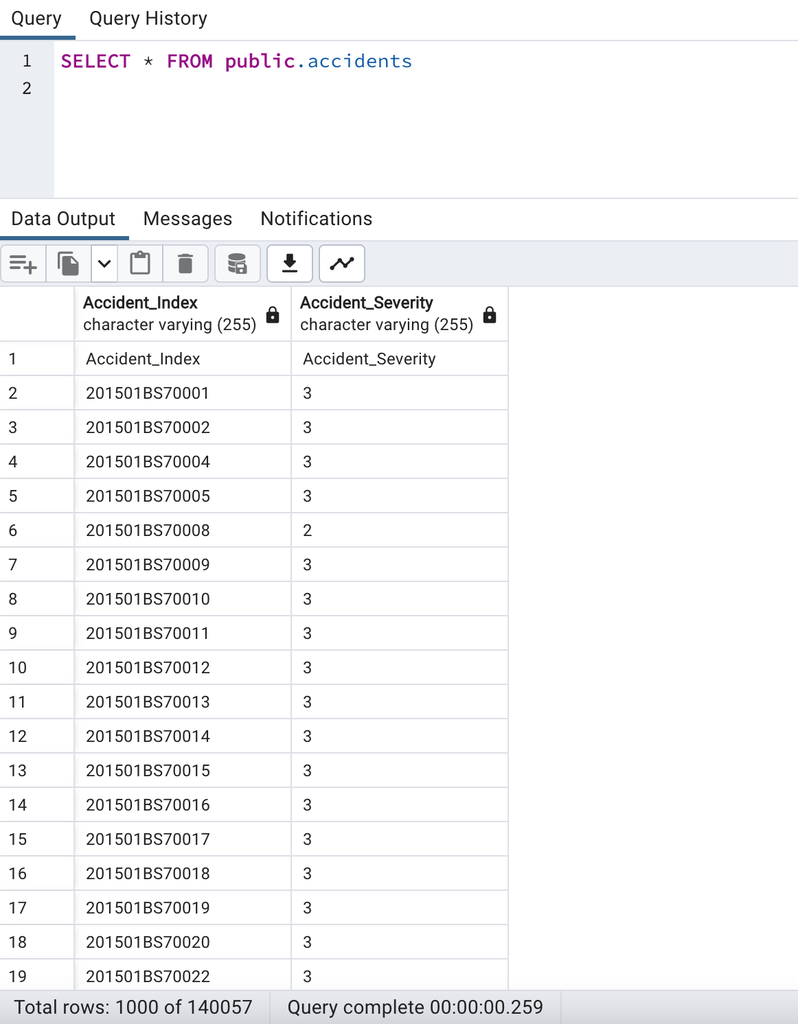

# creating a table for model

CREATE TABLE IF NOT EXISTS public.model ( “Accident_Index” character varying(255) COLLATE pg_catalog.”default”, “Vehicle_Type” character varying(255) COLLATE pg_catalog.”default” )

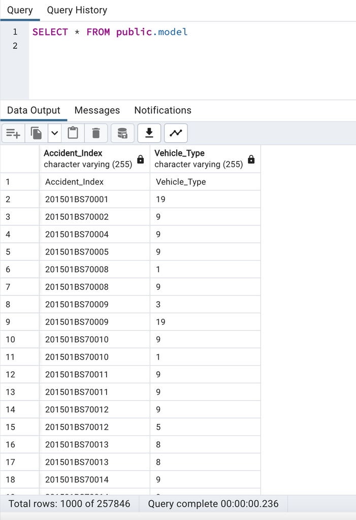

# creating a table for vehicle_type

CREATE TABLE IF NOT EXISTS public.vehicle_type ( code character varying(255) COLLATE pg_catalog.”default”, label character varying(255) COLLATE pg_catalog.”default” )

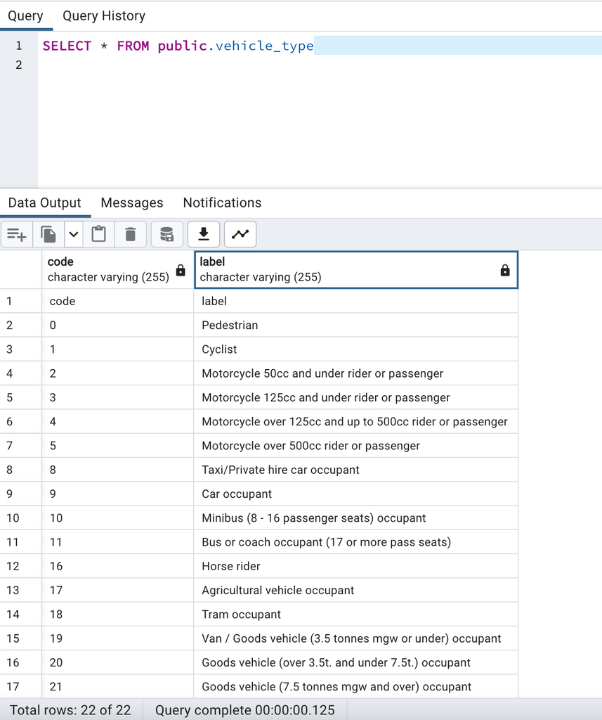

**2. Neo4j schema design and data load (35 pts)**

2.1 Schema design (10 pts) Draw the database schema for the graph database. You can use http://www.apcjones.com/ arrows, or draw it on paper and add a picture of it.

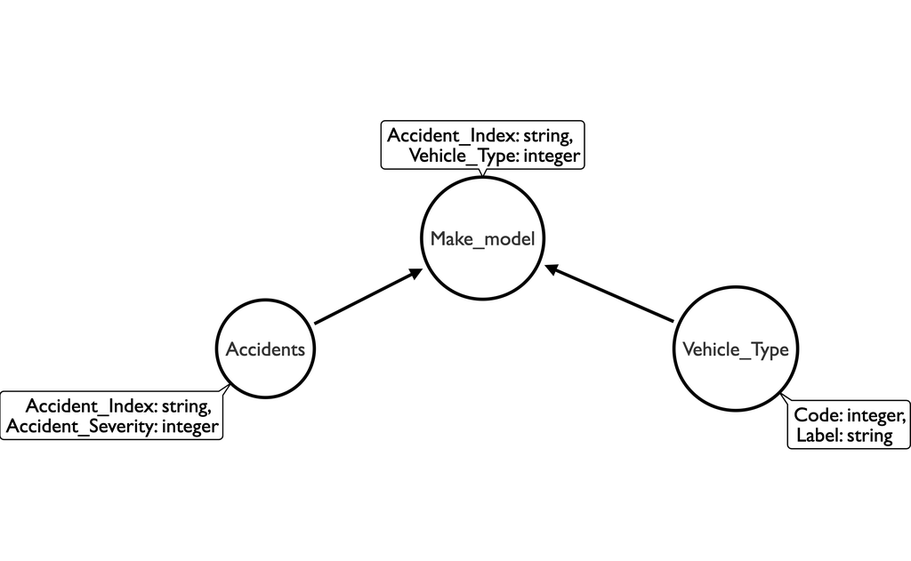

**2.2 Data load (25 pts) List the Cypher queries to load the data in the database.**

CREATE (:Accidents (‘Accident Index:’‘, ’Accident Severity’: 0}); CREATE (:Make Model { ‘Accident Index’: ’‘, ’Vehicle Type’: 0}); CREATE (:Vehicle_Type {Code: 0, Label:’’});

LOAD CSV WITH HEADERS FROM ‘file:///Accidents.csv’ AS row CREATE (:Accidents { ‘Accident Index’: row. ‘Accident Index’ , ‘Accident Severity’: toInteger (row. ‘Accident Severity’) }) LOAD CSV WITH HEADERS FROM file:///Make_Model.csv’ AS row CREATE (:Make_Model { ‘Accident Index’: row. ‘Accident Index’ , ‘Vehicle Type’: toInteger (row. ‘Vehicle Type’) }) LOAD CSV WITH HEADERS FROM ‘file:///Vehicle_Type.csv’ AS row MERGE (:Vehicle Type { Code: toInteger (row. code), Label: row.label })

**3. MongoDB data load (5 pts)**

Follow the instructions from MongoDB to import data with MongoDB Compass. Include a screenshot of the loaded collection(s).

[figure not shown]

[figure not shown]

[figure not shown]

**4. Data analysis (60 pts: 20 pts each per SQL, Cypher, and MongoDB queries)**

# SQL query

SELECT vehicle_type.code, AVG(accidents.accident_severity) AS average_accident_severity, percentile_cont(0.5) WITHIN GROUP (ORDER BY accidents.accident_severity) AS median_accident_severity FROM accidents JOIN make_model ON accidents.accident_index = make_model.accident_index JOIN vehicle_type ON make_model.vehicle_type = vehicle_type.code WHERE vehicle_type.label ILIKE ‘%motorcycle%’ GROUP BY vehicle_type.code;

# Cypher query

MATCH (a:accidents)-[:accident_index]->(mm:make_model)-[:code]->(vt:vehicle_type) WHERE tolower(vt.label) CONTAINS “motorcycle” RETURN vt.label, AVG(a.Accident_Severity) as avg_severity MATCH (mm:make_model)-[:code]->(vt:vehicle_type) WHERE toLower(vt.label) CONTAINS ‘motorcycle’ WITH vt.label AS label, COLLECT(mm.Accident_Severity) AS severities WITH label, apoc.coll.sort(severities) AS sortedSeverities WITH label, CASE WHEN size(sortedSeverities) % 2 = 0 THEN (sortedSeverities[size(sortedSeverities) / 2] + sortedSeverities[(size(sortedSeverities) / 2) - 1]) / 2.0 ELSE sortedSeverities[(size(sortedSeverities) - 1) / 2] END AS medianSeverity RETURN label, medianSeverity

# MongoDB query

**Create intermediary collection with initial aggregation results** db.createCollection(“intermediary”) db.accident.aggregate([ {$lookup: {from: "model", localField: "accident_index", foreignField: "accident_index", as: "model"}}, {$unwind: “$model"}, {$lookup: {from:”vehicle_type”, localField: “model.vehicle_type”, foreignField: “code”, as: “vehicle_type”}}, {$unwind: "$vehicle_type”}, {$match: {"vehicle_type.label": /motorcycle/i}}, {$group: {_id: “$vehicle_type.code", avg_accident_severity: {$avg:”$accident_severity"}}}, {$out: “intermediary”}])

**Calculate median using additional queries on intermediary collection** db.intermediary.aggregate([ {$group: {_id: "$_id”, avg_accident_severity: {$first: "$avg_accident_severity”}, sorted_accident_severity: {$push: "$avg_accident_severity”}}}, {$project: {median_accident_severity: {$arrayElemAt: [“$sorted_accident_severity", {$floor: {$divide: [{$size:”$sorted_accident_severity”}, 2]} } ] } } } ])

db.accident.aggregate([ { $lookup: { from: “model”, localField: “accident_index”, foreignField: “accident_index”, as: “model” } }, { $unwind: "$model” }, { $lookup: { from: “vehicle_type”, localField: “model.vehicle_type”, foreignField: “code”, as: “vehicle_type” } }, { $unwind: "$vehicle_type” }, { $match: { “vehicle_type.label”: /motorcycle/i } }, { $group: { _id: "$vehicle_type.code”, average_accident_severity: { $avg: "$accident_severity” }, buckets: { $push: "$accident_severity” } } }, { $project: { _id: 1, average_accident_severity: 1, median_accident_severity: { $let: { vars: { count: { $size: "$buckets” }, middle: { $trunc: { $divide: [ { $size: "$buckets” }, 2 ] } } }, in: { $cond: { if: { $eq: [ { $mod: [ { $size: "$buckets” }, 2 ] }, 0 ] }, then: { $avg: [ { $arrayElemAt: [ "$buckets”, “$middle” ] }, { $arrayElemAt: [ "$buckets”, { $subtract: [ "$middle”, 1 ] } ] } ] }, else: { $arrayElemAt: [ "$buckets”, “$middle” ] } } } } } } } ])

**Results:**

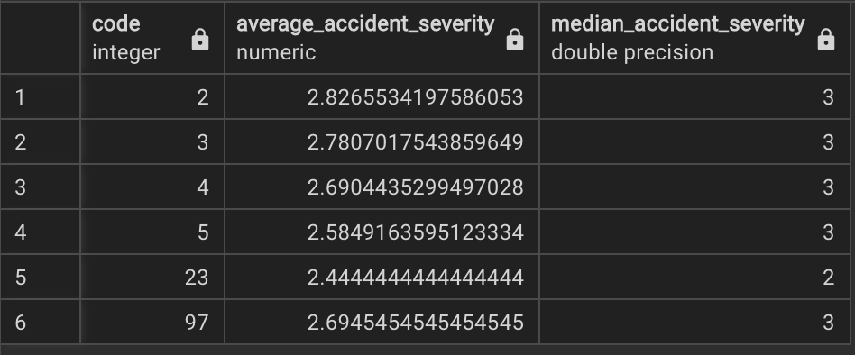